# Chapter 4: Deep Neural Networks

Based on material available at https://udlbook.github.io/udlbook/, by Prof. Simon Prince

Fernando Náufel

22/10/2026

## Deep neural networks

- Networks with more than one hidden layer
- Intuition becomes a little more difficult

## Deep neural networks

- Composing two networks
- Combining the two networks into one
- Hyperparameters
- Notation change and general case
- Shallow vs. deep networks

## Composing two networks

**Network 1**

$$\begin{aligned}
h_1 &= a[\theta_{10}+\theta_{11}x]\\
h_2 &= a[\theta_{20}+\theta_{21}x]\\
h_3 &= a[\theta_{30}+\theta_{31}x]\\[2mm]
y &= \phi_0+\phi_1h_1+\phi_2h_2+\phi_3h_3
\end{aligned}$$

**Network 2**

$$\begin{aligned}
h'_1 &= a[\theta'_{10}+\theta'_{11}y]\\
h'_2 &= a[\theta'_{20}+\theta'_{21}y]\\
h'_3 &= a[\theta'_{30}+\theta'_{31}y]\\[2mm]
y' &= \phi'_0+\phi'_1h'_1+\phi'_2h'_2+\phi'_3h'_3
\end{aligned}$$

[figure not shown]

## Composing two networks

[figure not shown]

## “Folding analogy”

[figure not shown]

[Play with interactive figure.](https://udlbook.github.io/udlfigures/)

## Comparing to shallow with six hidden units

**Deep architecture** — 20 parameters; at least 9 regions.

[figure not shown]

**Shallow architecture** — 19 parameters; maximum 7 regions.

[figure not shown]

## Composing networks in 2D

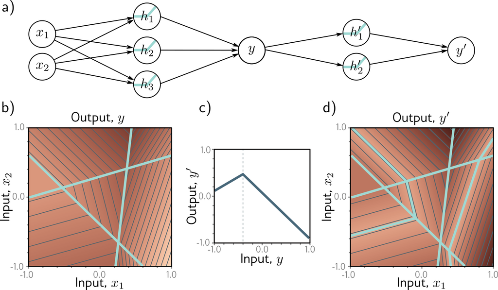

## Deep neural networks

- Composing two networks
- Combining the two networks into one
- Hyperparameters
- Notation change and general case
- Shallow vs. deep networks

## Combine two networks into one

Output of the first network is fed into the second network:

[figure not shown]

$$\begin{aligned}
h_1 &= a[\theta_{10}+\theta_{11}x]\\
h_2 &= a[\theta_{20}+\theta_{21}x]\\
h_3 &= a[\theta_{30}+\theta_{31}x]\\
y &= \phi_0+\sum_{j=1}^{3}\phi_j h_j\\
\end{aligned}$$

$$\begin{aligned}
h'_1 &= a[\theta'_{10}+\theta'_{11}y]\\
h'_2 &= a[\theta'_{20}+\theta'_{21}y]\\
h'_3 &= a[\theta'_{30}+\theta'_{31}y]\\
y' &= \phi'_0+\sum_{j=1}^{3}\phi'_j h'_j
\end{aligned}$$

Substitute the first output into the second hidden layer:

$$h'_i=a\!\left[\theta'_{i0}+\theta'_{i1}\phi_0+\sum_{j=1}^{3}\theta'_{i1}\phi_jh_j\right]$$

## Create new variables

[figure not shown]

In $\qquad\begin{cases} h'_1 &= a[\theta'_{10}+\theta'_{11}y]\\ h'_2 &= a[\theta'_{20}+\theta'_{21}y]\\ h'_3 &= a[\theta'_{30}+\theta'_{31}y]\\ y' &= \phi'_0+\sum_{j=1}^{3}\phi'_j h'_j \end{cases}\qquad$ define $\qquad\psi_{10}=\theta'_{i0}+\theta'_{i1}\phi_0,\qquad \psi_{ij}=\theta'_{i1}\phi_j,\quad i,j=1,2,3$

Then the hidden units of the second network become

$$\begin{aligned}
h'_1&=a[\psi_{10}+\psi_{11}h_1+\psi_{12}h_2+\psi_{13}h_3]\\
h'_2&=a[\psi_{20}+\psi_{21}h_1+\psi_{22}h_2+\psi_{23}h_3]\\
h'_3&=a[\psi_{30}+\psi_{31}h_1+\psi_{32}h_2+\psi_{33}h_3]
\end{aligned}$$

## Two-layer network

[figure not shown]

$$\begin{aligned}
h_1 &= a[\theta_{10}+\theta_{11}x] &
h'_1 &= a[\psi_{10}+\psi_{11}h_1+\psi_{12}h_2+\psi_{13}h_3]\\
h_2 &= a[\theta_{20}+\theta_{21}x] &
h'_2 &= a[\psi_{20}+\psi_{21}h_1+\psi_{22}h_2+\psi_{23}h_3]\\
h_3 &= a[\theta_{30}+\theta_{31}x] &
h'_3 &= a[\psi_{30}+\psi_{31}h_1+\psi_{32}h_2+\psi_{33}h_3]
\end{aligned}$$

$$y'=\phi'_0+\phi'_1h'_1+\phi'_2h'_2+\phi'_3h'_3$$

## Computed functions

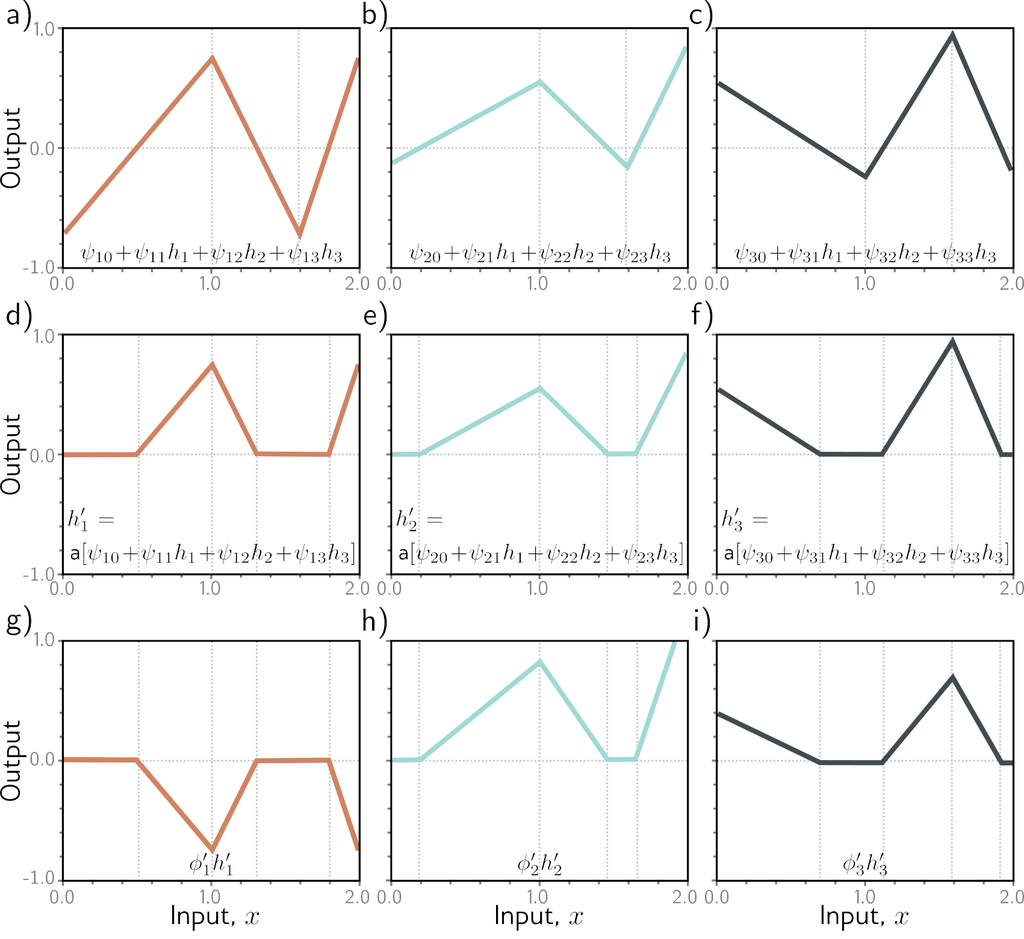

[figure not shown]

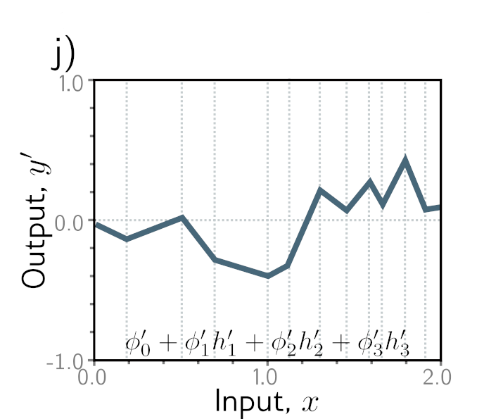

## Deep neural networks

- Composing two networks
- Combining the two networks into one
- Hyperparameters
- Notation change and general case
- Shallow vs. deep networks

## Hyperparameters

- $K$ layers = **depth** of network
- $D_k$ hidden units in layer $k, \quad 1 \leq k \leq K$.
- Not all layers need to have the same number of units.
- These are called **hyperparameters** — chosen before training the network.
- Can try retraining with different hyperparameters: **hyperparameter optimization** or **hyperparameter search**.

## Deep neural networks

- Composing two networks
- Combining the two networks into one
- Hyperparameters
- Notation change and general case
- Shallow vs. deep networks

## Notation change: matrix notation

[figure not shown]

$\begin{cases} h_1 = a[\theta_{10}+\theta_{11}x] \\ h_2 = a[\theta_{20}+\theta_{21}x] \\ h_3 = a[\theta_{30}+\theta_{31}x] \end{cases}$

$\quad\iff\quad \begin{bmatrix}h_1\\h_2\\h_3\end{bmatrix} =a\!\left[\begin{bmatrix}\theta_{10}\\\theta_{20}\\\theta_{30}\end{bmatrix} +\begin{bmatrix}\theta_{11}\\\theta_{21}\\\theta_{31}\end{bmatrix}x\right]$

$\begin{cases} h'_1 = a[\psi_{10}+\psi_{11}h_1+\psi_{12}h_2+\psi_{13}h_3] \\ h'_2 = a[\psi_{20}+\psi_{21}h_1+\psi_{22}h_2+\psi_{23}h_3] \\ h'_3 = a[\psi_{30}+\psi_{31}h_1+\psi_{32}h_2+\psi_{33}h_3] \end{cases}$

$\quad\iff\quad \begin{bmatrix}h'_1\\h'_2\\h'_3\end{bmatrix} = a\!\left[ \begin{bmatrix}\psi_{10}\\\psi_{20}\\\psi_{30}\end{bmatrix} +\begin{bmatrix}\psi_{11}&\psi_{12}&\psi_{13}\\\psi_{21}&\psi_{22}&\psi_{23}\\\psi_{31}&\psi_{32}&\psi_{33}\end{bmatrix} \begin{bmatrix}h_1\\h_2\\h_3\end{bmatrix} \right]$

$\begin{array}{l} \\ y'=\phi'_0 + \phi'_1h'_1 + \phi'_2h'_2 + \phi'_3h'_3 \end{array}$

$\quad\iff\quad y' = \phi'_0+ \begin{bmatrix}\phi'_1&\phi'_2&\phi'_3\end{bmatrix} \begin{bmatrix}h'_1\\h'_2\\h'_3\end{bmatrix}$

## Notation change: matrix notation

[figure not shown]

$\begin{cases} h_1 = a[\theta_{10}+\theta_{11}x] \\ h_2 = a[\theta_{20}+\theta_{21}x] \\ h_3 = a[\theta_{30}+\theta_{31}x] \end{cases}$

$\begin{array}{l} \\ \quad\iff\quad \mathbf h = a[\boldsymbol\theta_0+\boldsymbol\theta x] \end{array}$

$\begin{cases} h'_1 = a[\psi_{10}+\psi_{11}h_1+\psi_{12}h_2+\psi_{13}h_3] \\ h'_2 = a[\psi_{20}+\psi_{21}h_1+\psi_{22}h_2+\psi_{23}h_3] \\ h'_3 = a[\psi_{30}+\psi_{31}h_2+\psi_{32}h_2+\psi_{33}h_3] \end{cases}$

$\begin{array}{l} \\ \quad\iff\quad \mathbf h' = a[\boldsymbol\psi_0+\boldsymbol\Psi\mathbf h] \end{array}$

$\begin{array}{l} \\ y'=\phi'_0 + \phi'_1h'_1 + \phi'_2h'_2 + \phi'_3h'_3 \end{array}$

$\begin{array}{l} \\ \quad\iff\quad y' = \phi'_0+\boldsymbol\phi'\mathbf h' \end{array}$

## Notation change: matrix notation, with indices

[figure not shown]

$\begin{cases} h_1 = a[\theta_{10}+\theta_{11}x] \\ h_2 = a[\theta_{20}+\theta_{21}x] \\ h_3 = a[\theta_{30}+\theta_{31}x] \end{cases}$

$\begin{array}{l} \\ \quad\iff\quad \mathbf h_1 = \mathbf a[\boldsymbol\beta_0+\boldsymbol\Omega_0\mathbf x] \end{array}$

$\begin{cases} h'_1 = a[\psi_{10}+\psi_{11}h_1+\psi_{12}h_2+\psi_{13}h_3] \\ h'_2 = a[\psi_{20}+\psi_{21}h_1+\psi_{22}h_2+\psi_{23}h_3] \\ h'_3 = a[\psi_{30}+\psi_{31}h_2+\psi_{32}h_2+\psi_{33}h_3] \end{cases}$

$\begin{array}{l} \\ \quad\iff\quad \mathbf h_2 = \mathbf a[\boldsymbol\beta_1+\boldsymbol\Omega_1\mathbf h_1] \end{array}$

$\begin{array}{l} \\ y'=\phi'_0 + \phi'_1h'_1 + \phi'_2h'_2 + \phi'_3h'_3 \end{array}$

$\begin{array}{l} \\ \quad\iff\quad \mathbf y = \boldsymbol\beta_2+\boldsymbol\Omega_2\mathbf h_2 \end{array}$

## General equations for deep network

### (with *K* hidden layers)

$$\begin{aligned}
\mathbf h_1 &= \mathbf a[\boldsymbol\beta_0+\boldsymbol\Omega_0\mathbf x]\\
\mathbf h_2 &= \mathbf a[\boldsymbol\beta_1+\boldsymbol\Omega_1\mathbf h_1]\\
\mathbf h_3 &= \mathbf a[\boldsymbol\beta_2+\boldsymbol\Omega_2\mathbf h_2]\\
&\,\vdots\\
\mathbf h_K &= \mathbf a[\boldsymbol\beta_{K-1}+\boldsymbol\Omega_{K-1}\mathbf h_{K-1}]\\
\mathbf y &= \boldsymbol\beta_K+\boldsymbol\Omega_K\mathbf h_K
\end{aligned}$$

## Example

[figure not shown]

## Deep neural networks

- Composing two networks
- Combining the two networks into one
- Hyperparameters
- Notation change and general case
- Shallow vs. deep networks

## Shallow vs. deep networks

The best results are created by deep networks with many layers.

- 50–1000 layers for most applications
- Best results in:
  - Computer vision
  - Natural language processing
  - Graph neural networks
  - Generative models
  - Reinforcement learning
- All use deep networks.

## Shallow vs. deep networks

**1. Ability to approximate different functions?**

- Both obey the **universal approximation theorem**.
- Argument: one layer is enough, and for deep networks we could arrange for the other layers to compute the identity function.

## Shallow vs. deep networks

**2. Number of linear regions per parameter**

[figure not shown]

- **5 layers; 10 hidden units per layer:** 471 parameters, 161,501 linear regions
- **5 layers; 50 hidden units per layer:** 10,801 parameters, over $10^{40}$ linear regions

## Shallow vs. deep networks

**3. Depth efficiency**

- There are some functions that require a shallow network with **exponentially more hidden units** than a deep network to achieve an equivalent approximation.
- This is known as the **depth efficiency** of deep networks.
- But do the real-world functions we want to approximate have this property? **Unknown.**

## Shallow vs. deep networks

**4. Large structured networks**

- Think about images as input — might be 1M pixels.
- Fully connected networks are not practical.
- Answer is to have weights that only operate locally, and share across image.
- This leads to **convolutional networks**.
- Gradually integrate information from across the image — needs multiple layers.

## Shallow vs. deep networks

**5. Fitting and generalization**

- Fitting of deep models seems to be easier up to about 20 layers.
- Then needs various tricks to train deeper networks, so (in vanilla form), fitting becomes harder.
- Generalization is good in deep networks. Why?

## Shallow vs. deep networks

**5. Fitting and generalization**

Fitting of deep models is also **faster**.

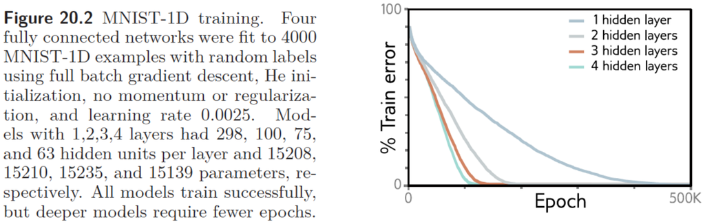

## Where are we going?

- We have defined families of very flexible networks that map multiple inputs to multiple outputs.
- Now we need to train them:
  - How to choose loss functions
  - How to find minima of the loss function
  - How to do this in particular for deep networks
- Then we need to test them.

## But before that

- Notebook 4.1 - Composing networks: [ipynb/colab](https://github.com/udlbook/udlbook/blob/main/Notebooks/Chap04/4_1_Composing_Networks.ipynb)
- Notebook 4.2 - Clipping functions: [ipynb/colab](https://github.com/udlbook/udlbook/blob/main/Notebooks/Chap04/4_2_Clipping_functions.ipynb)
- Notebook 4.3 - Deep networks: [ipynb/colab](https://github.com/udlbook/udlbook/blob/main/Notebooks/Chap04/4_3_Deep_Networks.ipynb)
- Problems for Chapter 4 [(see book)](https://udlbook.github.io/udlbook/)